# Home Assignment

Dor Polovincik

4/4/2021

# Question I

## KPIs Overview - General Population

```r
general_kpi <- kpi_calculator(df)  %>%
  mutate_at(1:6, round, 3)

formattable(general_kpi, align = rep('c', 6))
```

| total_orders | total_approved_volume | approval_rate | decline_rate | cb_rate | cb_paid |
| --- | --- | --- | --- | --- | --- |
| 190000 | 41674570 | 89.50% | 10.50% | 2.70% | 2158574 |

## Segmentation

The grouping set is based on the following features permutation:

- **billing_country_code**
- **shipping_country_code**
- **gateway**

I’ve also used the following features in order to show how Riskified can surpass current merchant solution:

- **V4_our_age**
- **V1_link**

## Groups KPI Distributions

### Number of Orders

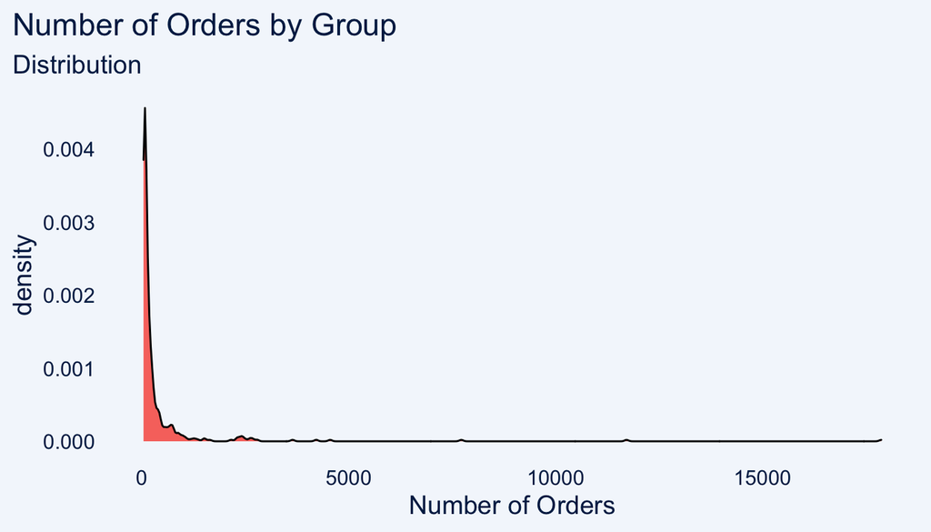

```r
required_features <- PARAMS$relevant_columns
df_aggregated <- kpi_calculator_multi(required_features) %>%
  filter(total_orders > 40) %>%
  mutate(ar_z = (approval_rate - mean(approval_rate))/sd(approval_rate),
         cbr_z = (cb_rate - mean(cb_rate))/sd(cb_rate))

df_aggregated %>%
  ggplot(aes(x=total_orders, fill= PARAMS$cols$customGreen0)) +
  geom_density() +
  theme_ggcharts() +
  labs(title = 'Number of Orders by Group',
       subtitle = 'Distribution',
       fill = '',
       x = 'Number of Orders') +
  theme(legend.position = 'none')
```

### Chargeback Rate

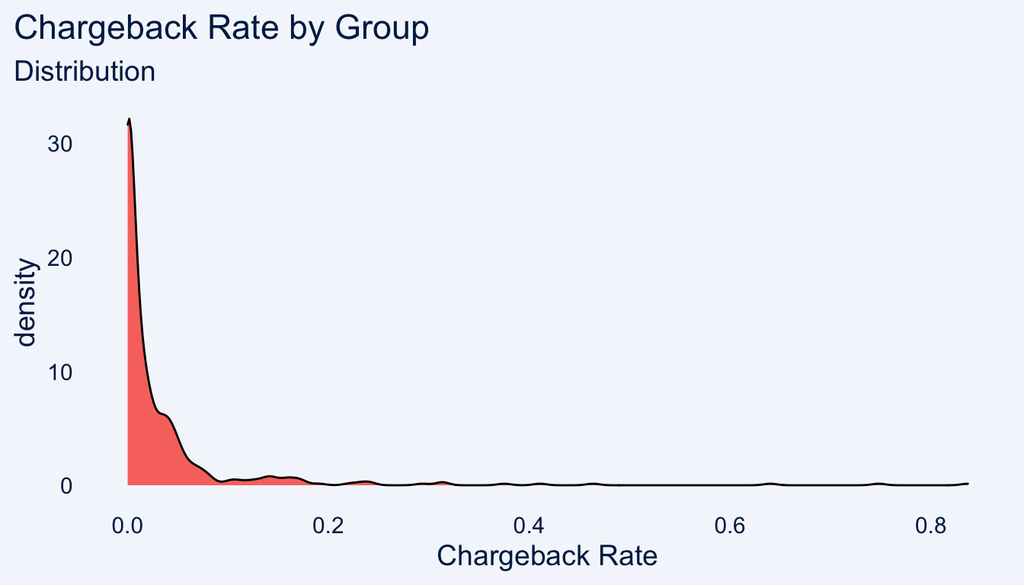

```r
df_aggregated %>%
  ggplot(aes(x=cb_rate, fill = PARAMS$cols$customGreen0)) +
  geom_density() +
  theme_ggcharts() +
  labs(title = 'Chargeback Rate by Group',
       subtitle = 'Distribution',
       fill = '',
       x = 'Chargeback Rate') +
  theme(legend.position = 'none')
```

### Approval Rate

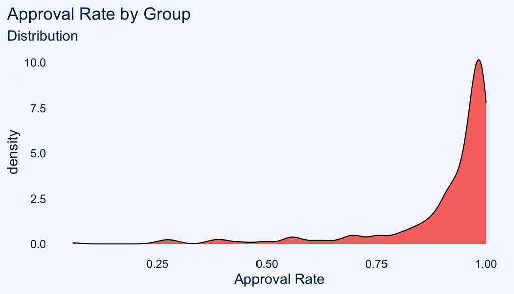

```r
df_aggregated %>%
  ggplot(aes(x=approval_rate, fill= PARAMS$cols$customGreen0)) +
  geom_density() +
  theme_ggcharts() +
  labs(title = 'Approval Rate by Group',
       subtitle = 'Distribution',
       fill = '',
       x = 'Approval Rate') +
  theme(legend.position = 'none')
```

## Risky Segments

**Risky segments** will be defined as groups with the following attributes:

- Relatively **low Approval Rate**
- Relatively **high Chargeback Rate**

With the assumption of transaction that are mostly to be declined while having relatively high chargeback rate within specific groups, are very risky and Riskified can do a better job in terms of fraud detection and increasing approval rate.

### Table

```r
df_risky <- df_aggregated  %>%
  filter(ar_z < -2, cbr_z > 2) %>%
  select(billing_country_code, shipping_country_code, gateway, total_orders,
         total_approved_volume, approval_rate, cb_rate) %>%
   mutate_at(4:7, round, 3) %>%
  arrange(desc(total_approved_volume), desc(total_orders))

formattable(df_risky, align =c("c","c","c","c","c", "c", "c"),
            list(
              `total_orders`= color_tile(customGreen0, customGreen),
              `total_approved_volume`= color_tile(customGreen0, customGreen),
              `approval_rate`= color_tile(customGreen0, customGreen),
              `cb_rate`= color_bar(customRed)
            ))
```

| billing_country_code | shipping_country_code | gateway | total_orders | total_approved_volume | approval_rate | cb_rate |
| --- | --- | --- | --- | --- | --- | --- |
| DE | DE | value_11 | 141 | 59304 | 54.60% | 22.10% |
| FR | FR | value_11 | 225 | 44349 | 55.10% | 24.20% |
| FR | FR | value_98 | 59 | 30018 | 27.10% | 31.20% |
| MX | MX | value_4 | 57 | 18921 | 56.10% | 37.50% |
| MX | MX | value_196 | 252 | 16172 | 44.40% | 41.10% |
| MX | MX | value_65 | 95 | 8107 | 27.40% | 23.10% |
| MX | MX | value_121 | 84 | 1812 | 29.80% | 64.00% |

### Chart

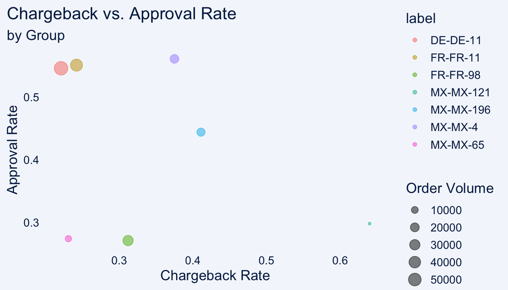

```r
df_risky %>%
  mutate(label = paste0(billing_country_code, '-', shipping_country_code, str_replace(gateway, 'value_', '-'))) %>%
  ggplot(aes(x=cb_rate, y=approval_rate, size=total_approved_volume, color=label)) +
  geom_point(alpha=0.5) +
  theme_ggcharts() +
  labs(title = 'Chargeback vs. Approval Rate',
       subtitle = 'by Group',
       fill = '',
       size = 'Order Volume',
       x = 'Chargeback Rate',
       y = 'Approval Rate') +
  theme(legend.position = 'right')
```

### Riskified Added Value

```r
df_riski_kpis <- df %>%
  group_by(across(required_features)) %>%
  summarise(avg_riski_age = round(mean(V4_our_age), 1),
            avg_mer_age =round( mean(V5_merchant_age), 1),
            linking = round(sum(V1_link)/n(), 2))

df_added_value <- df_risky %>%
  left_join(df_riski_kpis, by = required_features) %>%
  select(required_features, avg_riski_age, avg_mer_age, linking)

formattable(df_added_value, align =rep('c', 6))
```

| billing_country_code | shipping_country_code | gateway | avg_riski_age | avg_mer_age | linking |
| --- | --- | --- | --- | --- | --- |
| DE | DE | value_11 | 564.5 | 1.0 | 0.00 |
| FR | FR | value_11 | 536.8 | 1.0 | 0.00 |
| FR | FR | value_98 | 580.6 | 20.9 | 0.05 |
| MX | MX | value_4 | 446.3 | 17.2 | 0.00 |
| MX | MX | value_196 | 203.2 | 42.5 | 0.02 |
| MX | MX | value_65 | 658.6 | 99.5 | 0.01 |
| MX | MX | value_121 | 187.6 | 9.4 | 0.02 |

## Sub-Optimal Performance

**Sub-Optimal Performance** will be defined as groups with the following attributes:

- Relatively **low Approval Rate**
- Relatively **low Chargeback Rate**

With the assumption of transaction that are mostly to be declined while having relatively low chargeback rate within specific groups, could be approved safely more then they current are.

### Table

```r
df_sop <- df_aggregated  %>%
  filter(ar_z < -2, cbr_z < 0.25) %>%
  select(billing_country_code, shipping_country_code, gateway, total_orders,
         total_approved_volume, approval_rate, cb_rate) %>%
  mutate_at(4:7, round, 3) %>%
  arrange(desc(total_approved_volume), desc(total_orders))

formattable(df_sop, align =rep('c', ncol(df_sop)),
            list(
              `total_orders`= color_tile(customGreen0, customGreen),
              `total_approved_volume`= color_tile(customGreen0, customGreen),
              `approval_rate`= color_tile(customGreen0, customGreen),
              `cb_rate`= color_bar(customRed)
            ))
```

| billing_country_code | shipping_country_code | gateway | total_orders | total_approved_volume | approval_rate | cb_rate |
| --- | --- | --- | --- | --- | --- | --- |
| US | US | value_245 | 11715 | 1084448 | 56.00% | 3.70% |
| US | US | value_167 | 630 | 37431 | 53.80% | 4.40% |
| DE | DE | value_180 | 79 | 34732 | 57.00% | 0.00% |
| US | US | value_40 | 48 | 14665 | 60.40% | 0.00% |
| MX | MX | value_202 | 242 | 11394 | 36.80% | 2.20% |
| GB | GB | value_70 | 55 | 10985 | 47.30% | 0.00% |
| FR | FR | value_80 | 50 | 8943 | 58.00% | 3.40% |
| MX | MX | value_169 | 183 | 8747 | 28.40% | 3.80% |
| US | US | value_176 | 84 | 6568 | 42.90% | 0.00% |
| ID | ID | value_196 | 68 | 3925 | 39.70% | 0.00% |
| CA | US | value_245 | 69 | 788 | 5.80% | 0.00% |

### Chart

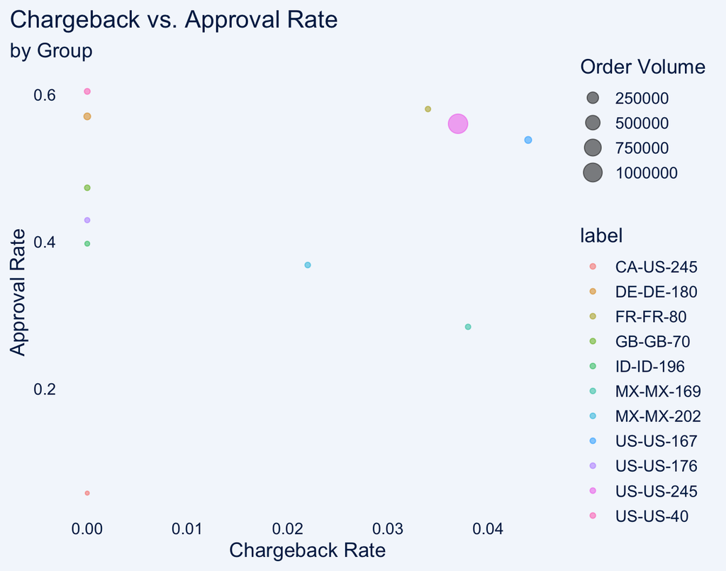

```r
df_sop %>%
  mutate(label = paste0(billing_country_code, '-', shipping_country_code, str_replace(gateway, 'value_', '-'))) %>%
  ggplot(aes(x=cb_rate, y=approval_rate, size=total_approved_volume, color=label)) +
  geom_point(alpha=0.5) +
  theme_ggcharts() +
  labs(title = 'Chargeback vs. Approval Rate',
       subtitle = 'by Group',
       fill = '',
       size = 'Order Volume',
       x = 'Chargeback Rate',
       y = 'Approval Rate') +
  theme(legend.position = 'right')
```

### Riskified Added Value

```r
df_added_value_sop <- df_sop %>%
  left_join(df_riski_kpis, by = required_features) %>%
  select(required_features, avg_riski_age, avg_mer_age, linking)

formattable(df_added_value_sop, align =rep('c', ncol(df_added_value_sop)))
```

| billing_country_code | shipping_country_code | gateway | avg_riski_age | avg_mer_age | linking |
| --- | --- | --- | --- | --- | --- |
| US | US | value_245 | 971.0 | 154.4 | 0.01 |
| US | US | value_167 | 851.4 | 636.7 | 0.01 |
| DE | DE | value_180 | 640.3 | 1.0 | 0.00 |
| US | US | value_40 | 1116.1 | 122.1 | 0.02 |
| MX | MX | value_202 | 700.6 | 391.3 | 0.01 |
| GB | GB | value_70 | 829.2 | 1.0 | 0.00 |
| FR | FR | value_80 | 573.7 | 119.4 | 0.02 |
| MX | MX | value_169 | 591.4 | 107.6 | 0.00 |
| US | US | value_176 | 704.8 | 37.9 | 0.04 |
| ID | ID | value_196 | 564.0 | 28.8 | 0.00 |
| CA | US | value_245 | 1198.7 | 0.6 | 0.00 |

# Question II

### Fitting a Predictive Model

Executed by Python (base code under classifier.py)

```python
from classifier import ModelExplained

try:
   # instance = ModelExplained(iteration_range=[500, 5000])
   # instance.main()
   print('Uncomment commands in order to trigger the model training proccess')
except Exception as e:
   print(e)
```

```
## Uncomment commands in order to trigger the model training proccess
```

## Model Evaluation

### Threshold

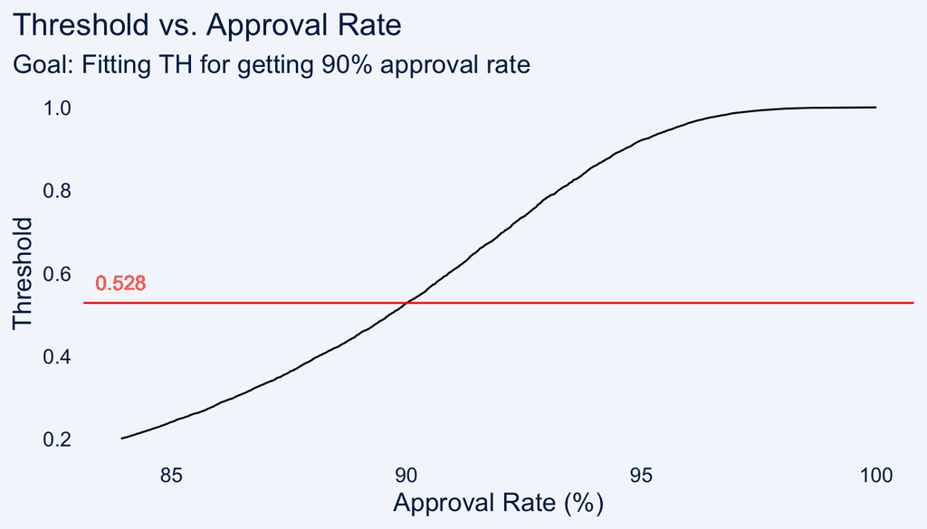

```r
df_th <- read.csv('data/plots/threshold.csv')

max_val <- df_th %>%
  mutate(delta = approval_rate-90) %>%
  summarise(ar = min(approval_rate[delta > 0]),
            th = min(threshold[approval_rate >= ar]),
            min_ar = min(approval_rate))

df_th %>%
  ggplot(aes(x=approval_rate, y=threshold)) +
  geom_line()  +
  theme_ggcharts() +
  labs(title = 'Threshold vs. Approval Rate',
       subtitle = 'Goal: Fitting TH for getting 90% approval rate',
       y = 'Threshold',
       x = 'Approval Rate (%)',
       col = '') +
  geom_hline(yintercept = max_val$th, col='red') +
  geom_text(aes(label=paste0(max_val$th),
                x = max_val$min_ar,
                y = max_val$th + 0.05,
                col = 'red')) +
  theme(legend.position = 'none')
```

### Evaluation Metrics

#### Chossing Hyper Parameters

- Number of Trees
- Learning Rate
- Depth

```r
df_hyper_params <- read.csv('data/plots/hyper_params.csv')
df_prauc <- read.csv('data/plots/dataset_prauc.csv')

df_show <- df_hyper_params %>% arrange(desc(prauc)) %>%
  select(trees, learning_rate, depth, prauc, roc_auc) %>% head(10) %>%
  mutate_at(1:5, round, 2)

formattable(df_show, align =rep('c', ncol(df_show)),  lapply(1:nrow(df_show), function(row) {
  area(row= 1, col = 1:ncol(df_show)) ~ color_tile("lightpink", "lightpink")
}))
```

| trees | learning_rate | depth | prauc | roc_auc |
| --- | --- | --- | --- | --- |
| 5000.00 | 0.17 | 7.00 | 0.52 | 0.78 |
| 5000 | 0.17 | 8 | 0.52 | 0.78 |
| 5000 | 0.16 | 8 | 0.51 | 0.78 |
| 500 | 0.16 | 8 | 0.51 | 0.78 |
| 5000 | 0.18 | 8 | 0.51 | 0.78 |
| 500 | 0.17 | 8 | 0.51 | 0.78 |
| 5000 | 0.16 | 7 | 0.51 | 0.78 |
| 500 | 0.18 | 8 | 0.51 | 0.78 |
| 5000 | 0.18 | 7 | 0.51 | 0.78 |
| 500 | 0.18 | 7 | 0.51 | 0.77 |

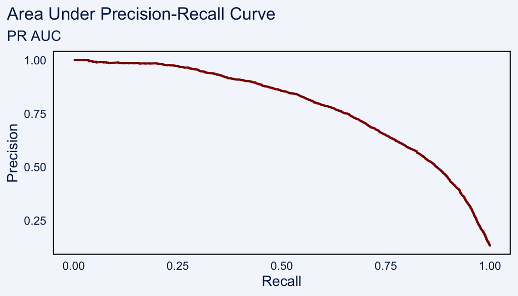

```r
df_prauc %>%
  ggplot(aes(x=recall, y=precision)) +
  geom_line(size = 1, col = 'darkred') +
  theme_ggcharts() +
  labs(title = 'Area Under Precision-Recall Curve',
       subtitle = 'PR AUC',
       x = 'Recall',
       y = 'Precision',
       color = '') +
  theme(legend.position = 'none',
        panel.border = element_rect(colour = "black", fill=NA, size=1))
```

### Business Interpretation

```r
df_th <- read.csv('data/plots/threshold.csv')

threshold <- df_th %>% mutate(delta = approval_rate-90) %>%
  summarise(ar = approval_rate[abs(delta) == min(abs(delta))],
            th = min(threshold[approval_rate >= ar])) %>%
  filter(ar >= 90)

df_test <- read.csv('data/plots/dataset_test.csv')

mutated_df_test <- df_test %>%
  mutate(model_declined = ifelse(model_score_1 >= threshold$th, T, F),
         model_status = case_when(
           model_declined ~ 'declined',
           (!model_declined) & status != 'chargeback' ~ 'approved',
           (!model_declined) & status == 'chargeback' ~ 'chargeback'))

performence_kpi <- mutated_df_test %>%
  summarise(
    order_count = n(),
    approval_rate_mer = sum(status != 'declined')/order_count,
    approval_rate_riski = sum(model_status != 'declined')/order_count,
    cb_count_mer = sum(status == 'chargeback'),
    cb_count_riski = sum(model_status == 'chargeback'),
    cb_paid_mer = sum(total_spent[status == 'chargeback']),
    cb_paid_riski = sum(total_spent[model_status == 'chargeback']),
    cb_rate_dollar_mer = cb_paid_mer/sum(total_spent[status != 'declined']),
    cb_rate_dollar_riski = cb_paid_riski/sum(total_spent[model_status != 'declined']),
    cb_rate_count_mer = cb_count_mer/sum(status != 'declined'),
    cb_rate_count_riski = cb_count_riski/sum(model_status != 'declined'),
    cb_saved_dollar = cb_paid_mer-cb_paid_riski,
    cb_saved_count = cb_count_mer-cb_count_riski,
    required_fee = 2*cb_paid_riski/sum(total_spent[model_status != 'declined'])
  )

output <- model_performence_comp(performence_kpi, 'mer') %>%
  left_join(model_performence_comp(performence_kpi, 'riski'), on = c('variable'))

cb_saved_pct <- paste0(round(performence_kpi$cb_saved_count*100/performence_kpi$cb_count_mer, 2), '%')
mutated_df_test <- mutated_df_test %>% filter(model_status == 'approved', status != 'declined') %>% count()

formattable(output, align =rep('c', 3))
```

| variable | Merchant | Riskified |
| --- | --- | --- |
| order_count | 38000 | 38000 |
| approval_rate | 89.43% | 90.01% |
| cb_count | 982 | 495 |
| cb_paid | 489023 | 205393 |
| cb_rate_dollar | 5.8% | 2.47% |
| cb_rate_count | 2.89% | 1.45% |

# Question III

Based on the performance of the model I trained, the **fee** that we should quote the merchant in order **total cost of chargebacks to be 50% of our total revenue** will be calculated as follow:

- **volume**: Total volume of transactions that were approved (including chargebacks)
- **chargeback**: Chargeback paid by Riskified (according to the suggested model)
- **fee**: Required fee

$$\frac{1}{2} = \frac{chargeback}{volume*fee}$$
$$fee = \frac{2*chargeback}{volume}$$

- Calculated result:

```r
data <- tibble(`Required Fee` = paste0(round(performence_kpi$required_fee*100, 3),'%'))

formattable(data, align =rep('c', 1),  lapply(1:nrow(data), function(row) {
  area(row= 1, col = 1:1) ~ color_tile("lightblue", "lightblue")
}))
```

| Required Fee |
| --- |
| 4.947% |

# Bonus Question

The probability that my model will score the approved order higher than the chargeback is the ROC AUC metric, as presented bellow.

```r
roc_auc <- (df_hyper_params %>% filter(prauc == max(prauc)) %>% head(1))$roc_auc
data_roc_auc <- tibble(`ROC AUC` = paste0(round(roc_auc*100, 3),'%'))

formattable(data_roc_auc, align =rep('c', 1),  lapply(1:nrow(data), function(row) {
  area(row= 1, col = 1:1) ~ color_tile("lightblue", "lightblue")
}))
```

| ROC AUC |
| --- |
| 78.25% |

```r
# consider:
# data_approved <- mutated_df_test %>% filter(model_status != 'declined')
# val <- auc(data_approved$y, data_approved$model_score_1)
```